# Связь школьного климата и сэс с образовательными достижениями по математической грамотности в международном сравнительном исследовании PISA 2012 в странах Прибалтики и России.

Выполнили: Альфия Заляева и Михаил Панфилов.

# Актуальность

Еще в 1982 году Дж. Коулман сделал акцент на том, что роль школьных факторов во многом важна и не менее важна роль семей учащихся в достижении высоко уровня образовательных результатов [Coleman, Hoffer, Kilgore, 1982]. Позднее, в 1993 году, вышла работа, где школьный климат рассматривался как одним из основных предикторов успешности обучения и имел прямую связь с достижениями учашихся [Kreft, 1993]. В настоящее время исследованиями связанными со школьным климатом занимались Т.А Чиркина и Т.Е. Хавенсон, в своей работе они подчеркивают, что школьный климат “признан важным детерминантом эффективности работы образовательных учреждений,учебных достижений, мотивации, социализации и поведения учеников.” [Чиркина, Хавенсон, 2017]. Однако, стоит отметить в России чаще всего испытывают дискомфорт в школе дети из семей с низким социально-экономическим статусом, а также ученики с низкими результатами по всем трем предметам [Дашкова, 2020]. Россия и страны Прибалтики (Эстония, Латвия, Литва) имеют общее прошлое, когда данные страны были в составе СССР. При этом, во всех союзных республиках проходила унификация образовательного процесса, которая позволяла создать равенство образовательных возможностей среди школьников [Вендина и др., 2016]. Однако, после распада Советского союза, эстонские школьники с 2006 года начали показывать более высокие результаты чем в России [Republic of Estonia. Ministry of education and research., 2018]. Именно поэтому в данном исследовании мы хотим посмотреть есть ли связь выделенных переменных школьного климата и сэс с образовательными результатами у когда-то унифицированных стран. В нашем исследовании мы используем переменные, которые выделили исследователи для PISA 2012 о школьном климате.

# Исследовательский вопрос

Имеют ли связь социальное положение семьи, школьный климат и пол с образовательными результатами учащихся в выделенных странах?

# Цель исследования

Эмпирический анализ связи школьного климата, индекса СЭС и пола с образовательными достижениями по математике между Россией и странами Прибалтики на примере PISA 2012.

# Этапы исследования

Для ответа на поставленный иисследовательский вопрос нами был определны этапы работы с данными:

## Первый этап

Это отбор переменых, связанные со школьным климатом. В исследовании PISA 2012 исследователи выделили 6 вопросов, которые относятся к изучению школьного климата: поддержка со стороны учителя математики (Mathematics Teacher Support), дисциплина в классе (Classroom Management), взаимоотношения с учителем (Teacher-Student Relation), чувство принадлежности к школе (Sense of Belonging to School), отношение к школе (Attitude Towards School: Learning Outcomes), отношение к занятиям (Attitude Towards School: Learning Activities).

В своей работе мы использовали: STUDREL - Взаимоотношение с учителями. В нее вошли переменны с ответами на следующие вопросы: Учащиеся ладят с большинством преподавателей. (ST86Q01) Большинство преподавателей интересуются жизнью учащихся. (ST86Q02) Большинство моих преподавателей действительно слушают то, что я говорю. (ST86Q03) Если мне нужна дополнительная помощь, я получу ее от моих преподавателей. (ST86Q04) Большинство моих преподавателей относятся ко мне справедливо. (ST86Q05)

BELONG - Чувство принадлежности к школы. В нее вошли переменны с ответами на следующие вопросы: Я чувствую себя изолированным от коллектива. (ST87Q01) Я легко завожу себе друзей в образовательном учреждении. (ST87Q02) Я чувствую себя частью образовательного учреждения. (ST87Q03) Я чувствую себя неловко, не на своем месте в образовательном учреждении. (ST87Q04) Мне кажется, что я нравлюсь другим учащимся. (ST87Q05) Я чувствую себя одиноким в образовательном учреждении. (ST87Q06) Я чувствую себя счастливым в образовательном учреждении. (ST87Q07) Все в моем образовательном учреждении идеально. (ST87Q08) Я доволен своим образовательным учреждением. (ST87Q09)

ATSCHL - отношение к школе: результаты обучения В нее вошли переменны с ответами на следующие вопросы: Образовательное учреждение мало сделало, чтобы подготовить меня к взрослой жизни после его окончания. (ST88Q01) Занятия в образовательном учреждении были пустой тратой времени. (ST88Q02) Образовательное учреждение научило меня принимать решения. (ST88Q03) Образовательное учреждение научило меня тому, что может пригодиться в дальнейшей работе. (ST88Q04)

ATTLNACT - отношение к школе: учебная деятельность В нее вошли переменны с ответами на следующие вопросы: Усердные занятия помогут мне получить хорошую работу. (ST89Q02) Усердные занятия помогут мне поступить в хороший университет (институт, колледж). (ST89Q03) Мне нравится получать хорошие отметкки. (ST89Q04) Усердные занятия очень важны для меня. (ST89Q05)

Данные вопросы синсетивные они все находятся в анкете для учащегося, а как нам известно анкетирование учащихся в PISA 2012 проводилось во всех странах.

## Второй этап

Определение метода работы с данными. В данном исследовании используется линейная регрессия.

Создание регрессионных моделей поможет нам углубиться в анализ связи школьного климата, сэс и образовательных результатов и определить значимость.

## Третий этап

Представление результатов исследования.

# Эмпирический анализ

## Подготовка и подгрузка пакетов

```r
library(tidyverse) #пакет для манипуляции с данными включает работу с графиками
library(intsvy) #пакет для работы с PISA и др.масштабными исследованиями
library(skimr) #пакет с описательной статистикой
library(car) #пакет для работы с регрессией
library(Hmisc) #для работы с переменными
library(sjPlot) #пакет для визуализации (соц.науки)
```

## Импортируем данные

В данном проекте использовалась база данных международного сравнительного исследования PISA 2012.

Описание исследования, базы данных с результатами исследования и кодбук расположенны на сайте OECD. https://www.oecd.org/pisa/data/pisa2012database-downloadabledata.htm

Технический отчет https://www.oecd.org/pisa/pisaproducts/PISA%202012%20Technical%20Report_Chapter%2016.pdf

```r
pisa_12 <- pisa.select.merge(folder = file.path(getwd(), "PISA 2012"),
  student.file = "PISA_Student_12.sav",
  student = c("ST04Q01", "ESCS", "STUDREL", "BELONG", "ATSCHL", "ATTLNACT"),
  countries = c("RUS","EST", "LTU", "LVA"))
```

Мы сформировали базу данных pisa_12 в которую вошли 4 страны: Россия, Эстония, Латвия и Литва. Для анализа были отобраны следующие переменные (индекса студенческого уровня): ST04Q01 - гендерный признак (половая принадлежность учащихся) ESCS - социально-экономический статус STUDREL - отношение учитель - ученик BELONG - чувство принадлежности к школе ATSCHL - отношение к школе: результаты обучения ATTLNACT - отношение к школе: учебная деятельность

## Описательная статистика

Посмотрим на наши данные: 1. Переменная с СЭС.

```r
skim(pisa_12$ESCS)
```

Data summary

| Name | pisa_12$ESCS |
| --- | --- |
| Number of rows | 18934 |
| Number of columns | 1 |
| _______________________ |  |
| Column type frequency: |  |
| numeric | 1 |
| ________________________ |  |
| Group variables | None |

**Variable type: numeric**

| skim_variable | n_missing | complete_rate | mean | sd | p0 | p25 | p50 | p75 | p100 | hist |
| --- | --- | --- | --- | --- | --- | --- | --- | --- | --- | --- |
| data | 241 | 0.99 | -0.06 | 0.84 | -4.04 | -0.7 | -0.03 | 0.63 | 3.69 | ▁▂▇▃▁ |

*Мы сразу определили, что в нашей переменной есть пропущенные значения (241). Однако, мы знаем, что это уже стандартизированная по всем странам шкала и переменная имеет нормальное распределение.*

2. Отношение между учеником и учителем.

```r
skim(pisa_12$STUDREL)
```

Data summary

| Name | pisa_12$STUDREL |
| --- | --- |
| Number of rows | 18934 |
| Number of columns | 1 |
| _______________________ |  |
| Column type frequency: |  |
| numeric | 1 |
| ________________________ |  |
| Group variables | None |

**Variable type: numeric**

| skim_variable | n_missing | complete_rate | mean | sd | p0 | p25 | p50 | p75 | p100 | hist |
| --- | --- | --- | --- | --- | --- | --- | --- | --- | --- | --- |
| data | 6452 | 0.66 | 0.15 | 0.98 | -3.11 | -0.48 | -0.02 | 0.81 | 2.16 | ▁▂▇▃▃ |

*Распределение не нормированно. Большое колличество пропущенных значений (6452). При нормирование возможны искажения в результатах по данной переменной.*

3. Чувство принадлежности к школе.

```r
skim(pisa_12$BELONG)
```

Data summary

| Name | pisa_12$BELONG |
| --- | --- |
| Number of rows | 18934 |
| Number of columns | 1 |
| _______________________ |  |
| Column type frequency: |  |
| numeric | 1 |
| ________________________ |  |
| Group variables | None |

**Variable type: numeric**

| skim_variable | n_missing | complete_rate | mean | sd | p0 | p25 | p50 | p75 | p100 | hist |
| --- | --- | --- | --- | --- | --- | --- | --- | --- | --- | --- |
| data | 6460 | 0.66 | -0.14 | 0.94 | -3.69 | -0.74 | -0.37 | 0.32 | 2.63 | ▁▂▇▃▁ |

*Аналогичная ситуация. Треть значений пропущенно (6460).*

4. Отношение учащихся к результатам обучения.

```r
skim(pisa_12$ATSCHL)
```

Data summary

| Name | pisa_12$ATSCHL |
| --- | --- |
| Number of rows | 18934 |
| Number of columns | 1 |
| _______________________ |  |
| Column type frequency: |  |
| numeric | 1 |
| ________________________ |  |
| Group variables | None |

**Variable type: numeric**

| skim_variable | n_missing | complete_rate | mean | sd | p0 | p25 | p50 | p75 | p100 | hist |
| --- | --- | --- | --- | --- | --- | --- | --- | --- | --- | --- |
| data | 6468 | 0.66 | 0.16 | 1.01 | -2.99 | -0.64 | -0.24 | 0.77 | 2.35 | ▁▃▇▆▃ |

*Распредление практические нормальное, есть небольшой скос вправо. Много пропущенных значений.*

5. Отношение учащихся к учебной деятельности.

```r
skim(pisa_12$ATTLNACT)
```

Data summary

| Name | pisa_12$ATTLNACT |
| --- | --- |
| Number of rows | 18934 |
| Number of columns | 1 |
| _______________________ |  |
| Column type frequency: |  |
| numeric | 1 |
| ________________________ |  |
| Group variables | None |

**Variable type: numeric**

| skim_variable | n_missing | complete_rate | mean | sd | p0 | p25 | p50 | p75 | p100 | hist |
| --- | --- | --- | --- | --- | --- | --- | --- | --- | --- | --- |
| data | 6439 | 0.66 | 0.02 | 0.97 | -3.38 | -0.94 | 0.09 | 1.21 | 1.21 | ▁▁▅▅▇ |

*Сильный скос данных вправо. Распределение не нормальное. Много пропущенных значений.*

6. Гендерная принадлежность учащихся.

```r
skim(pisa_12$ST04Q01)
```

Data summary

| Name | pisa_12$ST04Q01 |
| --- | --- |
| Number of rows | 18934 |
| Number of columns | 1 |
| _______________________ |  |
| Column type frequency: |  |
| numeric | 1 |
| ________________________ |  |
| Group variables | None |

**Variable type: numeric**

| skim_variable | n_missing | complete_rate | mean | sd | p0 | p25 | p50 | p75 | p100 | hist |
| --- | --- | --- | --- | --- | --- | --- | --- | --- | --- | --- |
| data | 0 | 1 | 1.5 | 0.5 | 1 | 1 | 1 | 2 | 2 | ▇▁▁▁▇ |

*Пропущенных значений в данной переменой нет. Общая сумма учащихся в данной переменной 18934. Гендерная принадлежность, как статистическая шкала является номинальной. В нашем случае мы видим, что она числовая и для дальнейшей работы нам необходимо ее перевести в класс факторных.*

Перекодируем переменную с гендерным различием.

```r
pisa_12$gend <- as.factor(pisa_12$ST04Q01)
attributes(pisa_12$gend) #проверим все ли хорошо с классами
```

```
## $levels
## [1] "1" "2"
##
## $class
## [1] "factor"
```

```r
levels(pisa_12$gend) <- c("girl", "boy") #присвоим нашим данных названия
table(pisa_12$gend) #проверим наши данные
```

```
##
## girl  boy
## 9494 9440
```

*В наших данных 9494 девочки и 9440 мальчика.*

Посмотрим на средние баллы по математике в Росии и странах Прибалтии.

```r
pisa.mean.pv(pvlabel = "MATH", by = "CNT", data = pisa_12)
```

```
##   CNT Freq   Mean s.e.    SD  s.e
## 1 EST 4779 520.55 2.02 80.90 1.17
## 2 LTU 4618 478.82 2.64 89.11 1.36
## 3 LVA 4306 490.57 2.75 81.87 1.51
## 4 RUS 5231 482.17 3.04 86.37 1.57
```

Посмотрим на распределение по гендерному различию внутри каждой выделенной страны.

```r
pisa.mean.pv(pvlabel = "MATH", by = c("CNT", "gend"), data = pisa_12)
```

```
##   CNT gend Freq   Mean s.e.    SD  s.e
## 1 EST girl 2409 517.93 2.21 78.21 1.52
## 2 EST  boy 2370 523.21 2.60 83.46 1.34
## 3 LTU girl 2283 478.74 2.97 85.85 1.77
## 4 LTU  boy 2335 478.91 2.84 92.21 1.56
## 5 LVA girl 2188 492.52 3.18 78.97 1.83
## 6 LVA  boy 2118 488.66 3.39 84.57 2.01
## 7 RUS girl 2614 482.94 3.06 85.61 1.70
## 8 RUS  boy 2617 481.39 3.69 87.12 1.87
```

Визуализируем наши данные.

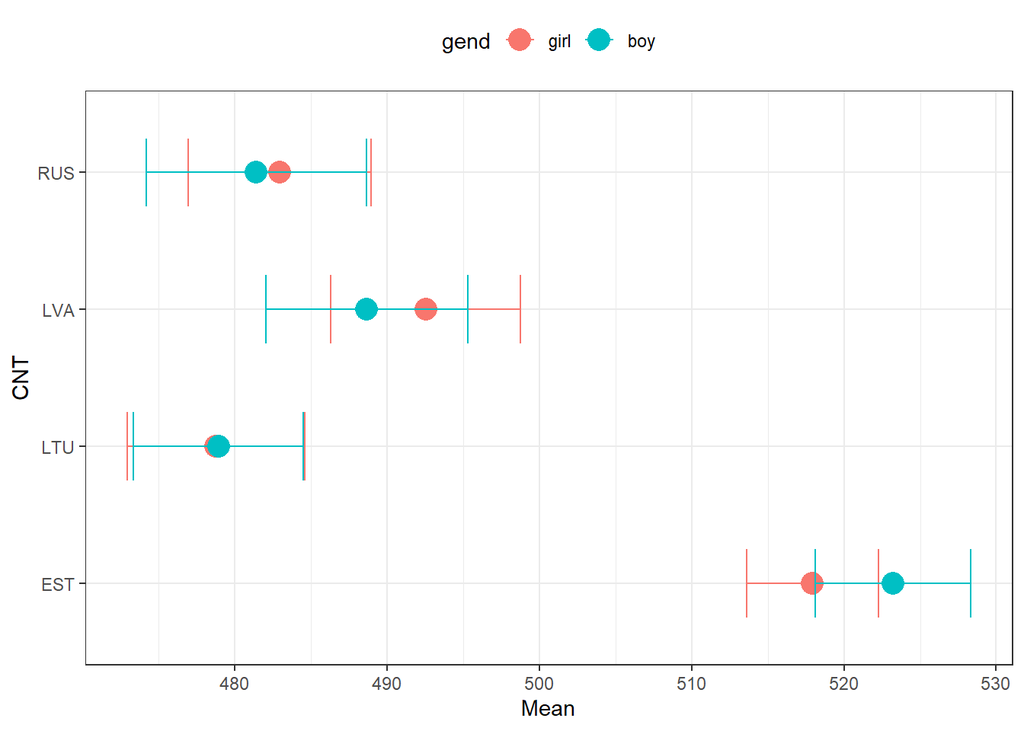

```r
mat_cnt <- pisa.mean.pv(pvlabel = "MATH", by = c("CNT", "gend"), data = pisa_12)
plot(mat_cnt)
```

*На графике представлены средние баллы по математике у мальчиков и девочек. Из описательной части мы видим, что в Эстонии у девочек балл слегка ниже (517,9), чем у мальчиков - 523,2. В Латвии у девочек - 492,5, а у мальчиков - 488,6. В России у девочек - 482,9, а у мальчиков - 481,3. В Литве практически не наблюдается различия, у девочек - 478,7, а у мальчиков - 478,9. На графике видно, что во всех страх доверительный интервал пересекается, отсюда следует, что значимых различий в баллах по математике у девочек и мальчиков нет.*

## Линейная регрессия

Используем переменную с баллами по математике в качестве зависимой переменной, а в качестве независимых прееменных выступают гендерный признак и СЭС учащихся.

```r
pisa_ses <- pisa.reg.pv(pvlabel = "MATH", x = c ("gend", "ESCS"), by = "CNT", data = pisa_12)
pisa_ses
```

```
## $EST
##             Estimate Std. Error t value
## (Intercept)   516.08       2.04  252.40
## gendboy         4.07       2.61    1.56
## ESCS           29.16       1.68   17.38
## R-squared       0.09       0.01    9.91
##
## $LTU
##             Estimate Std. Error t value
## (Intercept)   483.71       2.51  192.66
## gendboy         0.35       2.39    0.15
## ESCS           36.03       1.79   20.08
## R-squared       0.14       0.01   11.16
##
## $LVA
##             Estimate Std. Error t value
## (Intercept)   501.61       2.74  182.74
## gendboy        -2.99       3.25   -0.92
## ESCS           35.14       2.07   16.96
## R-squared       0.15       0.02    8.60
##
## $RUS
##             Estimate Std. Error t value
## (Intercept)   487.63       3.04  160.33
## gendboy        -2.13       2.94   -0.72
## ESCS           38.45       3.23   11.90
## R-squared       0.11       0.02    6.63
```

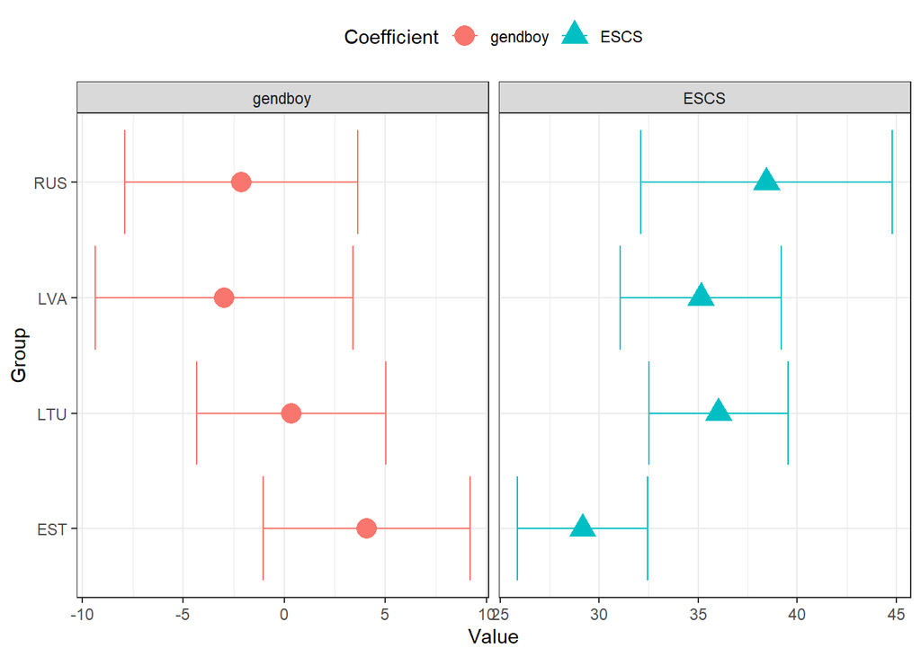

```r
plot(pisa_ses, vars = c("gend", "ESCS"))
```

Хотя, различия в баллах не серьезные они все же есть. Но, самое важное, в нашей модели мы рассматриваем СЭС и мы можем определить наличие или отсутствие связи и определить изменения баллов при увеличении на стандартное отклонение.

В России у мальчиков в среднем результаты ниже на 2,1 балла, чем у девочек. При увеличении индекса СЭС на одно стандартное отклонение баллы по математике увеличиваются на 38,4 балла (p<0,01). Коэффициент по гендерному признаку не значим.

В Литве у мальчиков баллы слегка выше (0,35), чем у девочек. А при увеличении индекса СЭС на одно стандартное отклонение баллы по математике растут на 36 баллов (p<0,01). Коэффициент по гендерному признаку не значим.

Отсюда следует, что во всех исследуемых странах нет значимого различия в баллах по гендерному признаку. Однако, значим индекс СЭС. Вывод: У детей из семей с высоким индексом СЭС результаты в математике выше независимо от их гендерной принадлежности.

## Регрессионные модели

В нашем исследовании мы делаем акцент на работе с образовательными результатами по математике, школьным климатом и сэс, для того, чтобы у нас получилась корректная интерпретация, нам необходимо нормировать наши данные.

Стандартизируем переменные с баллами по математике.

```r
for (varname in c("PV1MATH","PV2MATH", "PV3MATH","PV4MATH","PV5MATH")) {pisa_12[varname] <- scale(pisa_12[varname])}
summary(pisa_12$PV5MATH) #проверим, что получилось.
```

```
##     PV5MATH
##  Min.   :-3.71492
##  1st Qu.:-0.69529
##  Median :-0.01225
##  Mean   : 0.00000
##  3rd Qu.: 0.68229
##  Max.   : 3.77333
```

Стандартизируем переменную с оценкой отношением ученика и учителя.

```r
pisa_12$studrel <- scale(pisa_12$STUDREL)
summary(pisa_12$studrel)
```

```
##        V1
##  Min.   :-3.329
##  1st Qu.:-0.644
##  Median :-0.174
##  Mean   : 0.000
##  3rd Qu.: 0.673
##  Max.   : 2.052
##  NA's   :6452
```

Стандартизируем переменную с внутринними ощущениями учащегося по отношению себя к школе.

```r
pisa_12$belong <- scale(pisa_12$BELONG)
summary(pisa_12$belong)
```

```
##        V1
##  Min.   :-3.787
##  1st Qu.:-0.636
##  Median :-0.240
##  Mean   : 0.000
##  3rd Qu.: 0.496
##  Max.   : 2.964
##  NA's   :6460
```

Стандартизируем переменную с отношением к результатам обучения.

```r
pisa_12$atschl <- scale(pisa_12$ATSCHL)
summary(pisa_12$atschl)
```

```
##        V1
##  Min.   :-3.128
##  1st Qu.:-0.797
##  Median :-0.401
##  Mean   : 0.000
##  3rd Qu.: 0.601
##  Max.   : 2.168
##  NA's   :6468
```

Стандартизируем переменную с отношением к учебной деятельности.

```r
pisa_12$attlnact <- scale(pisa_12$ATTLNACT)
summary(pisa_12$attlnact)
```

```
##        V1
##  Min.   :-3.494
##  1st Qu.:-0.986
##  Median : 0.070
##  Mean   : 0.000
##  3rd Qu.: 1.227
##  Max.   : 1.227
##  NA's   :6439
```

### Модель 1.

В модели 1 рассмотрим переменную с баллами по математике (зависимая переменная), а в качестве независимых переменных рассмотрим: гендерную принадлежность, индекс СЭС учащихся и отношение учащегося с учителем.

```r
pisa_m1 <- pisa.reg.pv(pvlabel = "MATH", x = c ("gend", "ESCS", "studrel" ), by = "CNT", data = pisa_12)
pisa_m1
```

```
## $EST
##             Estimate Std. Error t value
## (Intercept)     0.25       0.03    8.75
## gendboy         0.05       0.04    1.45
## ESCS            0.33       0.02   14.14
## studrel         0.03       0.03    1.30
## R-squared       0.09       0.01    7.53
##
## $LTU
##             Estimate Std. Error t value
## (Intercept)    -0.15       0.03   -4.70
## gendboy         0.01       0.03    0.29
## ESCS            0.41       0.02   17.51
## studrel         0.05       0.02    2.84
## R-squared       0.14       0.01    9.60
##
## $LVA
##             Estimate Std. Error t value
## (Intercept)     0.04       0.03    1.22
## gendboy         0.02       0.04    0.43
## ESCS            0.40       0.03   14.49
## studrel         0.00       0.03    0.08
## R-squared       0.14       0.02    8.00
##
## $RUS
##             Estimate Std. Error t value
## (Intercept)    -0.09       0.04   -2.35
## gendboy        -0.02       0.04   -0.54
## ESCS            0.42       0.04   10.73
## studrel        -0.01       0.02   -0.27
## R-squared       0.11       0.02    6.38
```

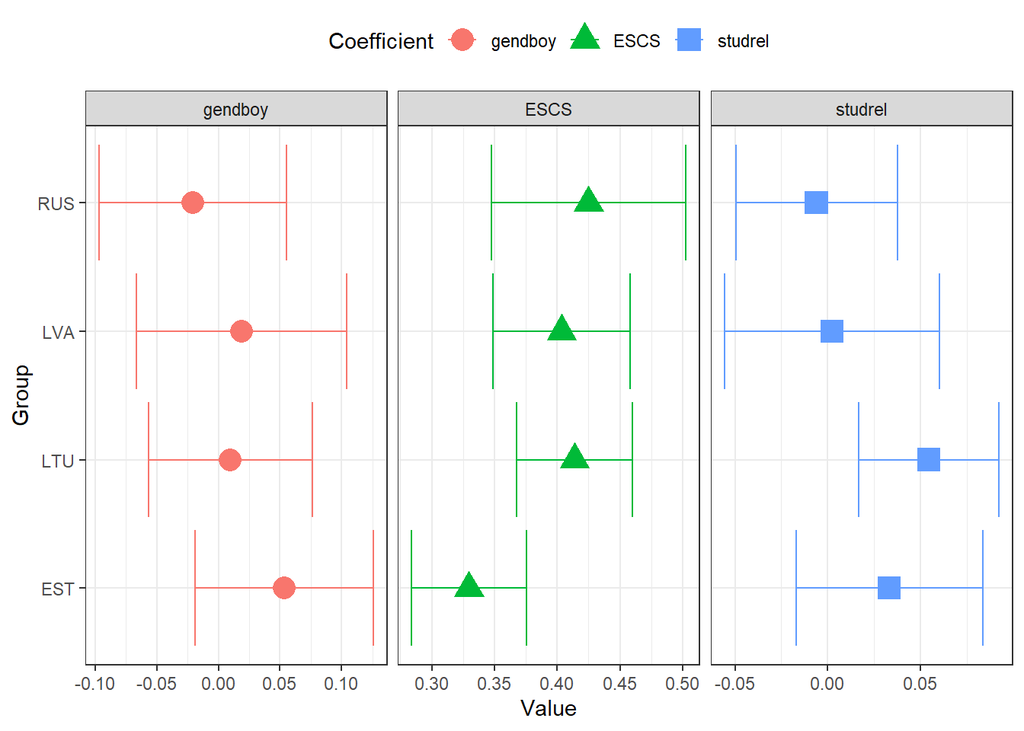

```r
plot(pisa_m1, vars = c ("gend", "ESCS", "studrel"))
```

Эстония: Полученная линейная регрессионная модель вида: Балл по математике = 0.25 + 0.05 x (пол ученика) + 0.33 x (индекс СЭС) + 0.03 x (studrel), т.е. при увеличении индекса СЭС, балл по математике увеличится на 0.33 (станд. отклонения), при увеличении коэф. “отношения учитель - ученик” на единицу балл по математике увеличится на 0.03 ст. откл. У мальчиков балл по математике выше на 0.05. О качестве модели свидетельствуют: коэффициент детерминации (Multiple R-squared), для данной модели равный 0.09, т.е. только 9% дисперсии зависимых переменных объясняется связь независимой переменной, что свидетельствует о низком качестве модели.

Литва: Полученная линейная регрессионная модель вида: Балл по математике = -0.15 + 0.01 x (пол ученика) + 0.41 x (индекс СЭС) + 0.05 x (studrel), т.е. при увеличении индекса СЭС, балл по математике увеличится на 0.41 (станд. отклонения), при увеличении коэф. “отношения учитель - ученик” на единицу балл по математике увеличится на 0.05 ст. откл. О качестве модели свидетельствуют: коэффициент детерминации (Multiple R-squared), для данной модели равный 0.14, т.е. только 14% дисперсии зависимых переменных объясняется связь независимой переменной, что свидетельствует о низком качестве модели.

Латвия: Полученная линейная регрессионная модель вида: Балл по математике = 0.04 + 0.02 x (пол ученика) + 0.40 x (индекс СЭС) + 0 x (studrel), т.е. при увеличении индекса СЭС, балл по математике увеличится на 0.40 (станд. отклонения), при увеличении коэф. “отношения учитель - ученик” на единицу балл по математике не изменится. О качестве модели свидетельствуют: коэффициент детерминации (Multiple R-squared), для данной модели равный 0.14, т.е. только 14% дисперсии зависимых переменных объясняется связь независимой переменной, что свидетельствует о низком качестве модели.

Россия: Полученная линейная регрессионная модель вида: Балл по математике = -0.09 - 0.02 x (пол ученика) + 0.42 x (индекс СЭС) – 0.01 x (studrel), т.е. при увеличении индекса СЭС, балл по математике увеличится на 0.42 (станд. отклонения), при увеличении коэф. “отношения учитель - ученик” на единицу балл по математике уменьшится на -0.01. О качестве модели свидетельствуют: коэффициент детерминации (Multiple R-squared), для данной модели равный 0.11, т.е. только 11% дисперсии зависимых переменных объясняется связь независимой переменной, что свидетельствует о низком качестве модели.

### Модель 2.

В модели 2 рассмотрим переменную с баллами по математике (зависимая переменная), а в качестве независимых переменных рассмотрим: гендерную принадлежность, индекс СЭС учащихся, отношение учащегося с учителем и чувство принадлежности к школе.

```r
pisa_m2 <- pisa.reg.pv(pvlabel = "MATH", x = c ("gend", "ESCS", "studrel", "belong" ), by = "CNT", data = pisa_12)
pisa_m2
```

```
## $EST
##             Estimate Std. Error t value
## (Intercept)     0.26       0.03    8.97
## gendboy         0.05       0.04    1.45
## ESCS            0.32       0.02   14.19
## studrel         0.01       0.03    0.43
## belong          0.05       0.02    2.21
## R-squared       0.09       0.01    7.54
##
## $LTU
##             Estimate Std. Error t value
## (Intercept)    -0.19       0.03   -5.96
## gendboy         0.03       0.03    0.93
## ESCS            0.39       0.02   16.89
## studrel        -0.01       0.02   -0.48
## belong          0.14       0.02    7.78
## R-squared       0.16       0.02   10.44
##
## $LVA
##             Estimate Std. Error t value
## (Intercept)     0.04       0.03    1.17
## gendboy         0.02       0.04    0.46
## ESCS            0.41       0.03   14.40
## studrel         0.02       0.03    0.59
## belong         -0.04       0.03   -1.42
## R-squared       0.15       0.02    8.03
##
## $RUS
##             Estimate Std. Error t value
## (Intercept)    -0.09       0.04   -2.36
## gendboy        -0.01       0.04   -0.38
## ESCS            0.42       0.04   10.57
## studrel        -0.02       0.03   -0.65
## belong          0.02       0.02    0.87
## R-squared       0.11       0.02    6.34
```

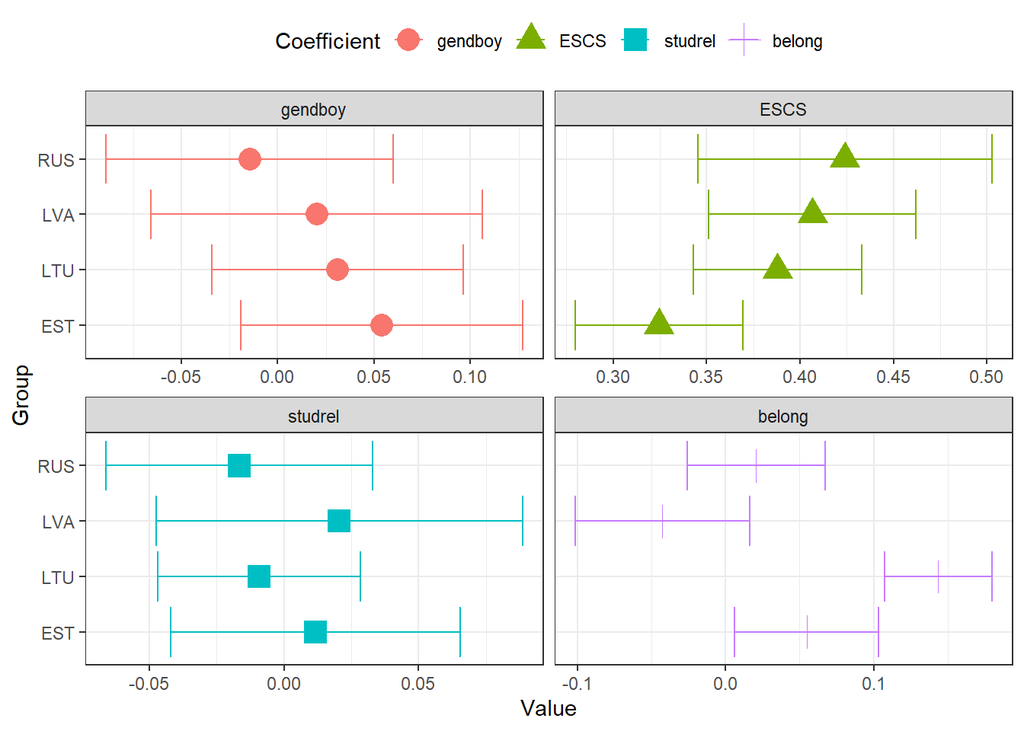

```r
plot(pisa_m2, vars = c ("gend", "ESCS", "studrel", "belong"))
```

### Модель 3.

В модели 3 рассмотрим переменную с баллами по математике (зависимая переменная), а в качестве независимых переменных рассмотрим: гендерную принадлежность, индекс СЭС учащихся, отношение учащегося с учителем, чувство принадлежности к школе и отношение к результатам обучения.

```r
pisa_m3 <- pisa.reg.pv(pvlabel = "MATH", x = c ("gend", "ESCS", "studrel", "belong", "atschl"), by = "CNT", data = pisa_12)
pisa_m3
```

```
## $EST
##             Estimate Std. Error t value
## (Intercept)     0.25       0.03    9.04
## gendboy         0.06       0.04    1.74
## ESCS            0.32       0.02   14.10
## studrel        -0.01       0.03   -0.23
## belong          0.03       0.03    0.97
## atschl          0.07       0.03    2.65
## R-squared       0.09       0.01    7.41
##
## $LTU
##             Estimate Std. Error t value
## (Intercept)    -0.21       0.03   -6.31
## gendboy         0.05       0.03    1.63
## ESCS            0.39       0.02   17.58
## studrel        -0.03       0.02   -1.86
## belong          0.11       0.02    5.43
## atschl          0.09       0.02    3.90
## R-squared       0.17       0.01   11.35
##
## $LVA
##             Estimate Std. Error t value
## (Intercept)     0.04       0.03    1.22
## gendboy         0.07       0.04    1.65
## ESCS            0.40       0.03   14.33
## studrel        -0.03       0.03   -0.86
## belong         -0.12       0.03   -3.84
## atschl          0.22       0.03    7.81
## R-squared       0.18       0.02    9.50
##
## $RUS
##             Estimate Std. Error t value
## (Intercept)    -0.09       0.04   -2.63
## gendboy        -0.01       0.04   -0.22
## ESCS            0.42       0.04   10.77
## studrel        -0.04       0.03   -1.61
## belong         -0.02       0.02   -1.04
## atschl          0.10       0.03    4.06
## R-squared       0.12       0.02    6.27
```

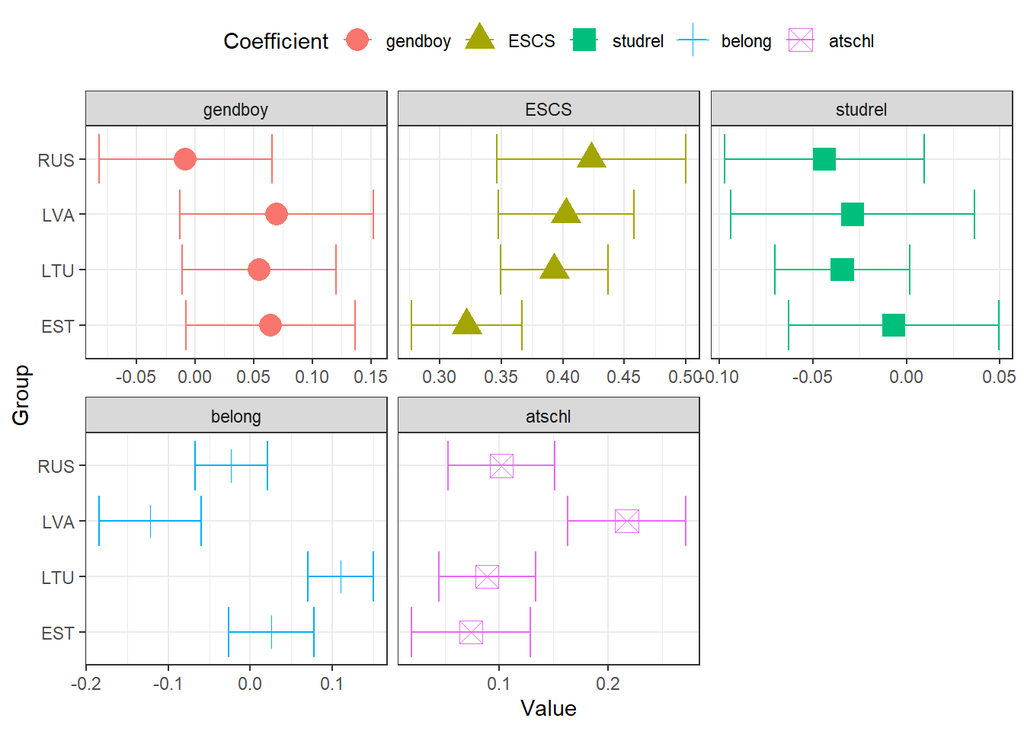

```r
plot(pisa_m3, vars = c ("gend", "ESCS", "studrel", "belong", "atschl"))
```

Литва: Балл по математике = - 0.21 + 0.05 x (пол ученика) + 0.39 x (индекс СЭС) - 0.03 x (studrel) + 0.11 x (belong) + 0,09 х (atshl) (отношение к результатам обучения), т.е. при увеличении индекса СЭС, балл по математике увеличится на 0.39 ст.отк, при увеличении коэф. “чувство принадлежности к школе” на единицу балл по математике увеличится 0.11 ст.отк., при увеличении коэф. “отношения учитель - ученик” на единицу балл по математике снизится незначительно – на 0.03 ст.откл. И у мальчиков балл по математике выше на 0.05. Коэффициент детерминации (Multiple R-squared) для данной модели равный 0.17, т.е. только 17% дисперсии зависимых переменных объясняется связь независимой переменной, что свидетельствует о низком качестве модели.

Латвия: Балл по математике = 0.04 + 0.07 x (пол ученика) + 0.40 x (индекс СЭС) - 0.03 x studrel - 0.12 x belong + 0,22 х atshl (отношение к результатам обучения), т.е. при увеличении индекса СЭС, балл по математике увеличится на 0.40 ст.отк, при увеличении коэф. “чувство принадлежности к школе” на единицу балл по математике уменьшится на - 0.12 ст.отк., при увеличении коэф. “отношения учитель - ученик” на единицу балл по математике снизится незначительно – на - 0.03 ст.откл. И у мальчиков балл по математике выше на 0.07. Коэффициент детерминации (Multiple R-squared) для данной модели равный 0.18, т.е. только 18% дисперсии зависимых переменных объясняется связь независимой переменной, что свидетельствует о низком качестве модели.

Россия: Балл по математике = -0.09 - 0.01 x (пол ученика) + 0.42 x (индекс СЭС) - 0.04 x (studrel) - 0.02 x (belong) + 0,10 х (atshl) (отношение к результатам обучения), т.е. при увеличении индекса СЭС, балл по математике увеличится на 0.42 ст.отк, при увеличении коэф. “чувство принадлежности к школе” на единицу балл по математике уменьшится на - 0.02 ст.отк., при увеличении коэф. “отношения учитель - ученик” на единицу балл по математике снизится незначительно – на - 0.04 ст.откл. У мальчиков балл по математике снизится на -0.01. Коэффициент детерминации (Multiple R-squared) для данной модели равный 0.12, т.е. только 12% дисперсии зависимых переменных объясняется связь независимой переменной, что свидетельствует о низком качестве модели.

### Модель 4.

В модели 4 рассмотрим переменную с баллами по математике (зависимая переменная), а в качестве независимых переменных рассмотрим: гендерную принадлежность, индекс СЭС учащихся, отношение учащегося с учителем, чувство принадлежности к школе, отношение к результатам обучения и учебной деятельности.

```r
pisa_m4 <- pisa.reg.pv(pvlabel = "MATH", x = c ("gend", "ESCS", "studrel", "belong", "atschl", "attlnact"), by = "CNT", data = pisa_12)
pisa_m4
```

```
## $EST
##             Estimate Std. Error t value
## (Intercept)     0.26       0.03    9.01
## gendboy         0.06       0.04    1.64
## ESCS            0.32       0.02   14.35
## studrel         0.00       0.03   -0.10
## belong          0.03       0.03    1.05
## atschl          0.08       0.03    2.97
## attlnact       -0.02       0.02   -1.04
## R-squared       0.09       0.01    7.51
##
## $LTU
##             Estimate Std. Error t value
## (Intercept)    -0.20       0.03   -6.10
## gendboy         0.05       0.03    1.54
## ESCS            0.39       0.02   17.48
## studrel        -0.03       0.02   -1.66
## belong          0.11       0.02    5.64
## atschl          0.09       0.02    3.94
## attlnact       -0.02       0.03   -0.62
## R-squared       0.17       0.01   11.37
##
## $LVA
##             Estimate Std. Error t value
## (Intercept)     0.04       0.03    1.28
## gendboy         0.06       0.04    1.49
## ESCS            0.40       0.03   14.47
## studrel        -0.02       0.03   -0.47
## belong         -0.11       0.03   -3.69
## atschl          0.24       0.03    8.16
## attlnact       -0.06       0.02   -2.58
## R-squared       0.18       0.02    9.60
##
## $RUS
##             Estimate Std. Error t value
## (Intercept)    -0.09       0.04   -2.62
## gendboy        -0.01       0.04   -0.16
## ESCS            0.42       0.04   10.68
## studrel        -0.04       0.03   -1.50
## belong         -0.03       0.02   -1.12
## atschl          0.10       0.03    3.64
## attlnact        0.01       0.02    0.42
## R-squared       0.11       0.02    6.09
```

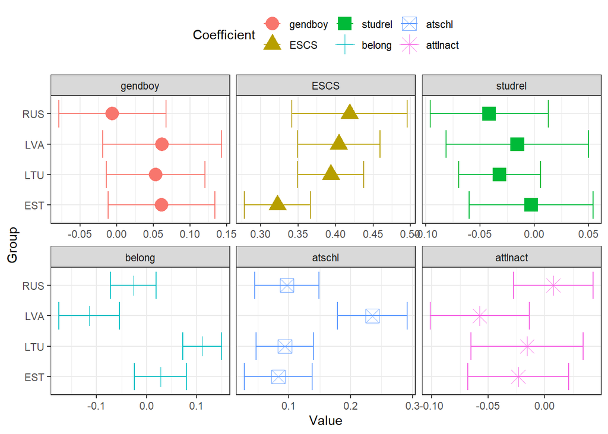

```r
plot(pisa_m4, vars = c ("gend", "ESCS", "studrel", "belong", "atschl", "attlnact"))
```

Эстония: Полученная линейная регрессионная модель вида: Балл по математике = 0.26 + 0.06 x (пол ученика) + 0.32 x (индекс СЭС) + 0 x (studrel) + 0.03 x (belong) + 0,08х (atshl) -0.02 х (attlnact), т.е. при увеличении индекса СЭС, балл по математике увеличится на 0.32 (станд. отклонения), при увеличении коэф. “отношения учитель - ученик” на единицу балл по математике не изменится, при увеличения коэф. “чувство принадлежности к школе” на единицу балл по математике увеличится 0.03, при увеличении коэф. “отношение к школе:результаты обучения” на единицу балл по математике увеличится на 0.08 ст. откл., при увеличении коэф. “отношение к школе:учебная деятельность” на единицу балл по математике уменьшится на - 0,02 ст.откл О качестве модели свидетельствуют: коэффициент детерминации (Multiple R-squared), для данной модели равный 0.09, т.е. только 9% дисперсии зависимых переменных объясняется связь независимой переменной, что свидетельствует о низком качестве модели.

Литва: Полученная линейная регрессионная модель вида: Балл по математике = -0.20 + 0.05 x (пол ученика) + 0.39 x (индекс СЭС) – 0.03 x (studrel) + 0.11 x (belong) + 0,09х (atshl) -0.02 х (attlnact), т.е. при увеличении индекса СЭС, балл по математике увеличится на 0.39 (станд. отклонения), при увеличении коэф. “отношения учитель - ученик” на единицу балл по математике уменьшится на -0.03 ст.откл., при увеличения коэф. “чувство принадлежности к школе” на единицу балл по математике увеличится 0.11, при увеличении коэф. “отношение к школе:результаты обучения” на единицу балл по математике увеличится на 0.09 ст. откл., при увеличении коэф. “отношение к школе:учебная деятельность” на единицу балл по математике уменьшится на - 0,02 ст.откл. О качестве модели свидетельствуют: коэффициент детерминации (Multiple R-squared), для данной модели равный 0.17, т.е. только 17% дисперсии зависимых переменных объясняется связь независимой переменной, что свидетельствует о низком качестве модели.

Латвия: Полученная линейная регрессионная модель вида: Балл по математике = 0,04 + 0.06 x (пол ученика) + 0.40 x (индекс СЭС) – 0.02 x (studrel) - 0.11 x (belong) + 0,24х (atshl) -0.06 х (attlnact), т.е. при увеличении индекса СЭС, балл по математике увеличится на 0.40 (станд. отклонения), при увеличении коэф. “отношения учитель - ученик” на единицу балл по математике уменьшится на -0.02 ст.откл., при увеличения коэф. “чувство принадлежности к школе” на единицу балл по математике уменьшится на - 0.11, при увеличении коэф. “отношение к школе:результаты обучения” на единицу балл по математике увеличится на 0.24 ст. откл., при увеличении коэф. “отношение к школе:учебная деятельность” на единицу балл по математике уменьшится на - 0,06 ст.откл. О качестве модели свидетельствуют: коэффициент детерминации (Multiple R-squared), для данной модели равный 0.18, т.е. только 18% дисперсии зависимых переменных объясняется связь независимой переменной, что свидетельствует о низком качестве модели.

Россия: Полученная линейная регрессионная модель вида: Балл по математике = -0,09 - 0.01 x (пол ученика) + 0.42 x (индекс СЭС) – 0.04 x (studrel) - 0.03 x (belong) + 0,10х (atshl) +0.01 х (attlnact), т.е. при увеличении индекса СЭС, балл по математике увеличится на 0.42 (станд. отклонения), при увеличении коэф. “отношения учитель - ученик” на единицу балл по математике уменьшится на -0.04 ст.откл., при увеличения коэф. “чувство принадлежности к школе” на единицу балл по математике уменьшится на - 0.03, при увеличении коэф. “отношение к школе:результаты обучения” на единицу балл по математике увеличится на 0.10 ст. откл., при увеличении коэф. “отношение к школе:учебная деятельность” на единицу балл по математике увеличится на 0,01 ст.откл. О качестве модели свидетельствуют: коэффициент детерминации (Multiple R-squared), для данной модели равный 0.11, т.е. только 11% дисперсии зависимых переменных объясняется связь независимой переменной, что свидетельствует о низком качестве модели.

# Результаты исследования

Также следует отметить, что в ходе интерпретации были выдвинуты гипотезы о том, что:

1. Нельзя с уверенностью сказать, что вопросы в школьных анкетах PISA отражающие школьный климат выражают объективное мнение, а не мнение о других явлениях.
2. Возможно, из-за данных синсетивных вопросов представляется сложным определить характер климата в школе т.к. суждения учащихся носят личный, ситуативный характер.

# Список источников

1. Вендина О., Колосов В., Себенцов А. “Является ли Прибалтика частью постсоветского пространства?” / Предисл. Н. Межевича. М.: Ассоциация книгоиздателей «Русская книга», 2016. 32 с. Рижим доступа: http://baltstudies.ru/upload/iblock/aa4/aa492745ad1f25e3aecd562d247da654.pdf (дата обращения: 16.06.2020)
2. Дашкова О. «Пизоподобность – причина снижения!» Часть вторая. Рижим доступа: https://vogazeta.ru/articles/2020/1/16/quality_of_education/11127-pizopodobnost__prichina_snizheniya_chast_vtoraya_ (дата обращения 24.06.2020)
3. Чиркина Татьяна Александровна, Хавенсон Татьяна Евгеньевна Школьный климат. История понятия, подходы к определению и измерение в анкетах PISA // Вопросы образования. 2017. №1. Режим доступа: https://cyberleninka.ru/article/n/shkolnyy-klimat-istoriya-ponyatiya-podhody-k-opredeleniyu-i-izmerenie-v-anketah-pisa (дата обращения: 16.06.2020).
4. Coleman J., HofferT., Kilgore S. (1982) Cognitive Outcomes in Public and Private Schools. Sociology of Education, vol. 55 (2), 65–76p. Режим доступа: https://www.jstor.org/stable/2112288?seq=1#metadata_info_tab_contents (дата обращения: 16.06.2020)
5. Kreft I.G. (1993) Using Multilevel Analysis to Assess School Effectiveness: A Study of Dutch Secondary Schools. Sociology of Education, vol. 66,(2) 104– 129p. Режим доступа: https://www.jstor.org/stable/2112796?seq=1#metadata_info_tab_contents (дата обращения: 16.06.2020)
6. PISA 2018: Estonia ranks first in Europe // Republic of Estonia. Ministry of education and research. Режим доступа: https://www.hm.ee/ru/meropriyatiya/issledovaniya-i-statistika/pisa (дата обращения: 16.06.2020)